# Sensitivity Analyses: Frailty Trajectories Before and After Incident Cancer

XZ

2026-04-30

## 1. Data Preparation

We integrate the time variables you generated (specifically `years_to_death`) to create a `terminal_decline` indicator.

```r
# Load your pre-processed dataset containing the calculated time variables
data_path <- "/n/home06/xyzhou/Frailty/2_data analysis/before and after cancer/data/FI_longitudinal_1986_2020_IMPUTED_Cancer.rds"
fi_long <- readRDS(data_path)

# 1. Re-establish Baseline Covariates (Cycle 86)
baseline_covs <- fi_long %>%
  filter(cycle == "86") %>%
  transmute(
    id,
    base_race    = as.factor(if_else(is.na(race), "Missing", as.character(race))),
    base_marital = as.factor(if_else(is.na(marital_status), "Missing", as.character(marital_status))),
    base_living  = as.factor(if_else(is.na(living_arr), "Missing", as.character(living_arr))),
    base_pckgr   = as.factor(if_else(is.na(pckgr), "Missing", as.character(pckgr)))
  )

# 2. Build the Analytic Dataset & Add Terminal Decline Indicator
analysis_long <- fi_long %>%
  filter(participated == 1, !is.na(fi_score_nocancer)) %>%
  left_join(baseline_covs, by = "id") %>%

  # Ensure we have baseline age Z-score (using age_at_cycle for the first observation)
  arrange(id, worked_rtmnyr) %>%
  group_by(id) %>%
  mutate(base_age = first(age_at_cycle)) %>%
  ungroup() %>%
  mutate(base_age_z = as.numeric(scale(base_age))) %>%

  # Remove Prevalent Cancers (cancer happened before or exactly at their first survey)
  group_by(id) %>%
  mutate(is_prevalent = if_else(!is.na(years_to_cancer) & first(years_to_cancer) >= 0, 1, 0)) %>%
  filter(is_prevalent == 0) %>%

  # Keep only those with at least 2 observations
  filter(n() >= 2) %>%
  ungroup() %>%

  # Generate Model Variables
  mutate(
    # Jump variable
    Cancer_Status = if_else(!is.na(years_to_cancer) & years_to_cancer >= 0, 1L, 0L),

    # Post-slope variable
    Years_Since_Cancer = if_else(Cancer_Status == 1L, years_to_cancer, 0),

    # NEW: Terminal Decline Indicator (Last year of life)
    # years_to_death is negative when the survey is taken BEFORE death.
    # Therefore, >= -1 and <= 0 captures the 12 months immediately preceding death.
    terminal_decline = if_else(!is.na(years_to_death) & years_to_death >= -1 & years_to_death <= 0, 1L, 0L)
  )

cat("Total observations:", nrow(analysis_long), "\n")
```

```
## Total observations: 628224
```

```r
cat("Total unique participants:", length(unique(analysis_long$id)), "\n")
```

```
## Total unique participants: 49921
```

## 2. Updated Main Model (Adjusted for Terminal Decline)

By adding the `terminal_decline` variable, the model “absorbs” the rapid spike in frailty that occurs right before death, preventing it from artificially steepening the `Years_Since_Cancer` slope (reducing survival bias).

```r
mod_main <- lmer(
  fi_score_nocancer ~ years_since_baseline + Cancer_Status + Years_Since_Cancer +
    terminal_decline + base_age_z + base_race + base_marital + base_living + base_pckgr +
    (1 + years_since_baseline | id),
  data = analysis_long,
  REML = TRUE,
  control = lmerControl(optimizer = "bobyqa", optCtrl = list(maxfun = 1e5))
)

summary(mod_main)
```

```
## Linear mixed model fit by REML. t-tests use Satterthwaite's method [
## lmerModLmerTest]
## Formula:
## fi_score_nocancer ~ years_since_baseline + Cancer_Status + Years_Since_Cancer +
##     terminal_decline + base_age_z + base_race + base_marital +
##     base_living + base_pckgr + (1 + years_since_baseline | id)
##    Data: analysis_long
## Control: lmerControl(optimizer = "bobyqa", optCtrl = list(maxfun = 1e+05))
##
## REML criterion at convergence: -1658905
##
## Scaled residuals:
##      Min       1Q   Median       3Q      Max
## -14.0247  -0.5031  -0.0746   0.4069  19.4972
##
## Random effects:
##  Groups   Name                 Variance  Std.Dev. Corr
##  id       (Intercept)          4.167e-03 0.064554
##           years_since_baseline 1.803e-05 0.004246 -0.05
##  Residual                      2.199e-03 0.046897
## Number of obs: 578240, groups:  id, 49893
##
## Fixed effects:
##                                  Estimate Std. Error         df t value
## (Intercept)                     8.199e-02  4.711e-03  4.880e+04  17.405
## years_since_baseline            6.220e-03  2.368e-05  3.929e+04 262.696
## Cancer_Status                  -1.981e-03  4.072e-04  5.521e+05  -4.866
## Years_Since_Cancer              2.971e-03  5.859e-05  2.626e+05  50.699
## terminal_decline                3.453e-02  5.851e-04  5.490e+05  59.008
## base_age_z                      2.106e-02  3.018e-04  4.882e+04  69.778
## base_raceAsian                 -1.313e-02  3.890e-03  4.922e+04  -3.376
## base_raceEuropean              -2.167e-02  3.106e-03  4.958e+04  -6.976
## base_raceMissing               -2.061e-02  3.548e-03  4.937e+04  -5.809
## base_raceOther                 -7.357e-03  3.908e-03  4.943e+04  -1.883
## base_maritalMarried            -6.588e-03  3.377e-03  4.831e+04  -1.951
## base_maritalMissing            -1.197e-02  4.748e-03  4.858e+04  -2.521
## base_maritalNever Married      -5.731e-03  3.410e-03  4.952e+04  -1.681
## base_maritalWidowed            -1.013e-02  2.533e-03  4.842e+04  -4.001
## base_livingMissing              3.391e-03  3.149e-03  4.890e+04   1.077
## base_livingOther                8.064e-03  3.498e-03  4.826e+04   2.305
```

[output cut: 20 more lines]

```
## base_maritalMissing            0.011715 *
## base_maritalNever Married      0.092852 .
## base_maritalWidowed            6.33e-05 ***
## base_livingMissing             0.281470
## base_livingOther               0.021161 *
## base_livingWith other family   0.083447 .
## base_livingWith spouse/partner 0.335036
## base_pckgr10-24 pack-years     0.007461 **
## base_pckgr25-44 pack-years      < 2e-16 ***
## base_pckgr45-64 pack-years      < 2e-16 ***
## base_pckgr65+ pack-years        < 2e-16 ***
## base_pckgrMissing              0.000801 ***
## base_pckgrNever                0.034591 *
## ---
## Signif. codes:  0 '***' 0.001 '**' 0.01 '*' 0.05 '.' 0.1 ' ' 1
```

```
## optimizer (bobyqa) convergence code: 0 (OK)
## Model is nearly unidentifiable: very large eigenvalue
##  - Rescale variables?
```

## 3. Sensitivity Analysis 1: Exclude Acute Phase (First 6 Months)

To ensure the “jump” isn’t just acute surgical or chemo toxicity, we drop any frailty measurements taken within 0.5 years (6 months) after diagnosis.

```r
# Filter out observations that occurred within 6 months post-cancer
data_sen1 <- analysis_long %>%
  filter(!(Cancer_Status == 1 & years_to_cancer <= 0.5))

mod_sen1 <- lmer(
  fi_score_nocancer ~ years_since_baseline + Cancer_Status + Years_Since_Cancer +
    terminal_decline + base_age_z + base_race + base_marital + base_living + base_pckgr +
    (1 + years_since_baseline | id),
  data = data_sen1,
  REML = TRUE,
  control = lmerControl(optimizer = "bobyqa", optCtrl = list(maxfun = 1e5))
)

summary(mod_sen1)
```

```
## Linear mixed model fit by REML. t-tests use Satterthwaite's method [
## lmerModLmerTest]
## Formula:
## fi_score_nocancer ~ years_since_baseline + Cancer_Status + Years_Since_Cancer +
##     terminal_decline + base_age_z + base_race + base_marital +
##     base_living + base_pckgr + (1 + years_since_baseline | id)
##    Data: data_sen1
## Control: lmerControl(optimizer = "bobyqa", optCtrl = list(maxfun = 1e+05))
##
## REML criterion at convergence: -1647101
##
## Scaled residuals:
##      Min       1Q   Median       3Q      Max
## -14.0102  -0.5027  -0.0747   0.4063  19.4790
##
## Random effects:
##  Groups   Name                 Variance  Std.Dev. Corr
##  id       (Intercept)          4.162e-03 0.064516
##           years_since_baseline 1.799e-05 0.004241 -0.05
##  Residual                      2.203e-03 0.046935
## Number of obs: 574672, groups:  id, 49893
##
## Fixed effects:
##                                  Estimate Std. Error         df t value
## (Intercept)                     8.192e-02  4.711e-03  4.881e+04  17.390
## years_since_baseline            6.219e-03  2.367e-05  3.922e+04 262.710
## Cancer_Status                  -2.879e-03  4.306e-04  5.472e+05  -6.685
## Years_Since_Cancer              3.030e-03  6.059e-05  2.634e+05  50.005
## terminal_decline                3.470e-02  5.937e-04  5.454e+05  58.448
## base_age_z                      2.107e-02  3.018e-04  4.882e+04  69.813
## base_raceAsian                 -1.316e-02  3.890e-03  4.924e+04  -3.383
## base_raceEuropean              -2.169e-02  3.107e-03  4.963e+04  -6.980
## base_raceMissing               -2.069e-02  3.549e-03  4.940e+04  -5.831
## base_raceOther                 -7.409e-03  3.908e-03  4.946e+04  -1.896
## base_maritalMarried            -6.534e-03  3.377e-03  4.830e+04  -1.935
## base_maritalMissing            -1.200e-02  4.747e-03  4.856e+04  -2.528
## base_maritalNever Married      -5.752e-03  3.410e-03  4.951e+04  -1.687
## base_maritalWidowed            -1.004e-02  2.533e-03  4.840e+04  -3.966
## base_livingMissing              3.504e-03  3.149e-03  4.890e+04   1.113
## base_livingOther                8.074e-03  3.498e-03  4.826e+04   2.308
```

[output cut: 20 more lines]

```
## base_maritalMissing            0.011469 *
## base_maritalNever Married      0.091615 .
## base_maritalWidowed            7.33e-05 ***
## base_livingMissing             0.265781
## base_livingOther               0.020989 *
## base_livingWith other family   0.080864 .
## base_livingWith spouse/partner 0.344863
## base_pckgr10-24 pack-years     0.006844 **
## base_pckgr25-44 pack-years      < 2e-16 ***
## base_pckgr45-64 pack-years      < 2e-16 ***
## base_pckgr65+ pack-years        < 2e-16 ***
## base_pckgrMissing              0.000638 ***
## base_pckgrNever                0.040568 *
## ---
## Signif. codes:  0 '***' 0.001 '**' 0.01 '*' 0.05 '.' 0.1 ' ' 1
```

```
## optimizer (bobyqa) convergence code: 0 (OK)
## Model is nearly unidentifiable: very large eigenvalue
##  - Rescale variables?
```

## 4. Sensitivity Analysis 2: Exclude High Baseline Frailty (Ceiling Effect)

We restrict the cohort to participants who were relatively robust/pre-frail (FI <= 0.25) at their very first measurement to ensure mathematical ceiling effects aren’t compressing the cancer jump.

```r
# Extract baseline FI for each person
baseline_fi <- analysis_long %>%
  group_by(id) %>%
  arrange(years_since_baseline) %>%
  slice(1) %>%
  select(id, base_fi = fi_score_nocancer) %>%
  ungroup()

# Filter dataset to only those with baseline FI <= 0.25
data_sen2 <- analysis_long %>%
  left_join(baseline_fi, by = "id") %>%
  filter(base_fi <= 0.25)

mod_sen2 <- lmer(
  fi_score_nocancer ~ years_since_baseline + Cancer_Status + Years_Since_Cancer +
    terminal_decline + base_age_z + base_race + base_marital + base_living + base_pckgr +
    (1 + years_since_baseline | id),
  data = data_sen2,
  REML = TRUE,
  control = lmerControl(optimizer = "bobyqa", optCtrl = list(maxfun = 1e5))
)

summary(mod_sen2)
```

```
## Linear mixed model fit by REML. t-tests use Satterthwaite's method [
## lmerModLmerTest]
## Formula:
## fi_score_nocancer ~ years_since_baseline + Cancer_Status + Years_Since_Cancer +
##     terminal_decline + base_age_z + base_race + base_marital +
##     base_living + base_pckgr + (1 + years_since_baseline | id)
##    Data: data_sen2
## Control: lmerControl(optimizer = "bobyqa", optCtrl = list(maxfun = 1e+05))
##
## REML criterion at convergence: -1664838
##
## Scaled residuals:
##      Min       1Q   Median       3Q      Max
## -14.2514  -0.5083  -0.0768   0.4114  19.7711
##
## Random effects:
##  Groups   Name                 Variance  Std.Dev. Corr
##  id       (Intercept)          3.130e-03 0.055948
##           years_since_baseline 1.774e-05 0.004212 0.01
##  Residual                      2.145e-03 0.046309
## Number of obs: 571638, groups:  id, 48829
##
## Fixed effects:
##                                  Estimate Std. Error         df t value
## (Intercept)                     7.464e-02  4.247e-03  4.873e+04  17.577
## years_since_baseline            6.273e-03  2.358e-05  3.913e+04 265.970
## Cancer_Status                  -1.915e-03  4.031e-04  5.508e+05  -4.751
## Years_Since_Cancer              2.954e-03  5.783e-05  2.592e+05  51.087
## terminal_decline                3.411e-02  5.857e-04  5.449e+05  58.226
## base_age_z                      1.738e-02  2.720e-04  4.887e+04  63.917
## base_raceAsian                 -1.113e-02  3.503e-03  4.924e+04  -3.176
## base_raceEuropean              -2.046e-02  2.808e-03  4.965e+04  -7.286
## base_raceMissing               -1.828e-02  3.205e-03  4.939e+04  -5.704
## base_raceOther                 -9.745e-03  3.534e-03  4.941e+04  -2.758
## base_maritalMarried            -2.978e-03  3.038e-03  4.816e+04  -0.981
## base_maritalMissing            -6.681e-03  4.273e-03  4.848e+04  -1.564
## base_maritalNever Married      -4.162e-03  3.097e-03  4.969e+04  -1.344
## base_maritalWidowed            -7.635e-03  2.281e-03  4.826e+04  -3.348
## base_livingMissing              2.926e-03  2.842e-03  4.888e+04   1.030
## base_livingOther                8.069e-03  3.142e-03  4.810e+04   2.568
```

[output cut: 20 more lines]

```
## base_maritalMissing            0.117914
## base_maritalNever Married      0.179004
## base_maritalWidowed            0.000815 ***
## base_livingMissing             0.303234
## base_livingOther               0.010217 *
## base_livingWith other family   0.043449 *
## base_livingWith spouse/partner 0.357859
## base_pckgr10-24 pack-years     0.009344 **
## base_pckgr25-44 pack-years      < 2e-16 ***
## base_pckgr45-64 pack-years      < 2e-16 ***
## base_pckgr65+ pack-years        < 2e-16 ***
## base_pckgrMissing              0.043165 *
## base_pckgrNever                0.027763 *
## ---
## Signif. codes:  0 '***' 0.001 '**' 0.01 '*' 0.05 '.' 0.1 ' ' 1
```

```
## optimizer (bobyqa) convergence code: 0 (OK)
## Model is nearly unidentifiable: very large eigenvalue
##  - Rescale variables?
```

## 5. Sensitivity Analysis 3: Quadratic Time (Non-Linear Normal Aging)

We add a squared term for baseline time to allow the “normal aging” trajectory to curve upward, checking if the cancer jump still remains significant.

```r
mod_sen3 <- lmer(
  fi_score_nocancer ~ years_since_baseline + I(years_since_baseline^2) +
    Cancer_Status + Years_Since_Cancer + I(Years_Since_Cancer^2) +
    terminal_decline + base_age_z + base_race + base_marital + base_living + base_pckgr +
    (1 + years_since_baseline | id),
  data = analysis_long,
  REML = TRUE,
  control = lmerControl(optimizer = "bobyqa", optCtrl = list(maxfun = 1e5))
)

summary(mod_sen3)
```

```
## Linear mixed model fit by REML. t-tests use Satterthwaite's method [
## lmerModLmerTest]
## Formula:
## fi_score_nocancer ~ years_since_baseline + I(years_since_baseline^2) +
##     Cancer_Status + Years_Since_Cancer + I(Years_Since_Cancer^2) +
##     terminal_decline + base_age_z + base_race + base_marital +
##     base_living + base_pckgr + (1 + years_since_baseline | id)
##    Data: analysis_long
## Control: lmerControl(optimizer = "bobyqa", optCtrl = list(maxfun = 1e+05))
##
## REML criterion at convergence: -1663669
##
## Scaled residuals:
##      Min       1Q   Median       3Q      Max
## -14.2756  -0.4972  -0.0740   0.3982  19.6834
##
## Random effects:
##  Groups   Name                 Variance  Std.Dev. Corr
##  id       (Intercept)          4.118e-03 0.064175
##           years_since_baseline 1.934e-05 0.004397 -0.05
##  Residual                      2.169e-03 0.046574
## Number of obs: 578240, groups:  id, 49893
##
## Fixed effects:
##                                  Estimate Std. Error         df t value
## (Intercept)                     8.715e-02  4.687e-03  4.879e+04  18.593
## years_since_baseline            4.783e-03  3.228e-05  1.346e+05 148.158
## I(years_since_baseline^2)       6.161e-05  9.090e-07  5.203e+05  67.778
## Cancer_Status                   8.358e-04  4.778e-04  5.400e+05   1.749
## Years_Since_Cancer              9.093e-04  1.066e-04  5.324e+05   8.528
## I(Years_Since_Cancer^2)         3.902e-05  5.045e-06  5.254e+05   7.735
## terminal_decline                3.116e-02  5.843e-04  5.492e+05  53.326
## base_age_z                      1.966e-02  3.008e-04  4.913e+04  65.340
## base_raceAsian                 -1.269e-02  3.870e-03  4.919e+04  -3.279
## base_raceEuropean              -2.108e-02  3.091e-03  4.957e+04  -6.819
## base_raceMissing               -2.004e-02  3.530e-03  4.935e+04  -5.675
## base_raceOther                 -6.890e-03  3.888e-03  4.940e+04  -1.772
## base_maritalMarried            -6.233e-03  3.360e-03  4.827e+04  -1.855
## base_maritalMissing            -1.155e-02  4.723e-03  4.854e+04  -2.446
## base_maritalNever Married      -5.457e-03  3.393e-03  4.950e+04  -1.608
```

[output cut: 25 more lines]

```
## base_maritalMissing             0.01444 *
## base_maritalNever Married       0.10775
## base_maritalWidowed            9.17e-05 ***
## base_livingMissing              0.30568
## base_livingOther                0.02470 *
## base_livingWith other family    0.08790 .
## base_livingWith spouse/partner  0.37026
## base_pckgr10-24 pack-years      0.01095 *
## base_pckgr25-44 pack-years      < 2e-16 ***
## base_pckgr45-64 pack-years      < 2e-16 ***
## base_pckgr65+ pack-years        < 2e-16 ***
## base_pckgrMissing               0.00126 **
## base_pckgrNever                 0.03747 *
## ---
## Signif. codes:  0 '***' 0.001 '**' 0.01 '*' 0.05 '.' 0.1 ' ' 1
```

```
## optimizer (bobyqa) convergence code: 0 (OK)
## Model is nearly unidentifiable: very large eigenvalue
##  - Rescale variables?
```

## 6. Sensitivity Analysis 4: Age as the Timescale

We swap `years_since_baseline` out for `age_at_cycle` as the primary biological clock. *Note: `base_age_z` is removed from the fixed effects here, because current age is already accounting for it.*

```r
mod_sen4 <- lmer(
  fi_score_nocancer ~ age_at_cycle + Cancer_Status + Years_Since_Cancer +
    terminal_decline + base_race + base_marital + base_living + base_pckgr +
    (1 + age_at_cycle | id),
  data = analysis_long,
  REML = TRUE,
  control = lmerControl(optimizer = "bobyqa", optCtrl = list(maxfun = 1e5))
)

summary(mod_sen4)
```

```
## Linear mixed model fit by REML. t-tests use Satterthwaite's method [
## lmerModLmerTest]
## Formula:
## fi_score_nocancer ~ age_at_cycle + Cancer_Status + Years_Since_Cancer +
##     terminal_decline + base_race + base_marital + base_living +
##     base_pckgr + (1 + age_at_cycle | id)
##    Data: analysis_long
## Control: lmerControl(optimizer = "bobyqa", optCtrl = list(maxfun = 1e+05))
##
## REML criterion at convergence: -1643291
##
## Scaled residuals:
##      Min       1Q   Median       3Q      Max
## -13.4025  -0.5034  -0.0737   0.4084  19.3198
##
## Random effects:
##  Groups   Name         Variance  Std.Dev. Corr
##  id       (Intercept)  0.0581996 0.241246
##           age_at_cycle 0.0000152 0.003898 -0.95
##  Residual              0.0022316 0.047240
## Number of obs: 578240, groups:  id, 49893
##
## Fixed effects:
##                                  Estimate Std. Error         df t value
## (Intercept)                    -2.399e-01  5.538e-03  4.885e+04 -43.317
## age_at_cycle                    5.805e-03  2.154e-05  4.322e+04 269.515
## Cancer_Status                  -8.317e-05  4.071e-04  5.520e+05  -0.204
## Years_Since_Cancer              3.327e-03  5.661e-05  2.972e+05  58.776
## terminal_decline                3.711e-02  5.863e-04  5.440e+05  63.292
## base_raceAsian                 -7.015e-03  4.450e-03  4.556e+04  -1.576
## base_raceEuropean              -1.928e-02  3.570e-03  4.675e+04  -5.402
## base_raceMissing               -1.849e-02  4.086e-03  4.679e+04  -4.525
## base_raceOther                 -8.644e-03  4.517e-03  4.716e+04  -1.914
## base_maritalMarried            -1.136e-02  3.840e-03  4.319e+04  -2.958
## base_maritalMissing            -1.774e-02  5.431e-03  4.464e+04  -3.266
## base_maritalNever Married      -4.541e-02  4.036e-03  5.206e+04 -11.251
## base_maritalWidowed            -9.302e-03  2.878e-03  4.300e+04  -3.232
## base_livingMissing             -3.375e-03  3.668e-03  4.765e+04  -0.920
## base_livingOther                1.811e-02  3.973e-03  4.303e+04   4.557
## base_livingWith other family    1.866e-02  2.509e-03  4.055e+04   7.435
```

[output cut: 18 more lines]

```
## base_maritalMissing             0.00109 **
## base_maritalNever Married       < 2e-16 ***
## base_maritalWidowed             0.00123 **
## base_livingMissing              0.35747
## base_livingOther               5.20e-06 ***
## base_livingWith other family   1.07e-13 ***
## base_livingWith spouse/partner  0.01982 *
## base_pckgr10-24 pack-years      0.15332
## base_pckgr25-44 pack-years     3.00e-09 ***
## base_pckgr45-64 pack-years     2.80e-08 ***
## base_pckgr65+ pack-years       7.18e-09 ***
## base_pckgrMissing               0.45076
## base_pckgrNever                 0.00184 **
## ---
## Signif. codes:  0 '***' 0.001 '**' 0.01 '*' 0.05 '.' 0.1 ' ' 1
```

```
## optimizer (bobyqa) convergence code: 0 (OK)
## Model failed to converge with max|grad| = 0.0439677 (tol = 0.002, component 1)
## Model is nearly unidentifiable: very large eigenvalue
##  - Rescale variables?
```

## 7. Results Comparison Summary

We extract the main coefficients of interest (the sudden jump and the aftermath slope) across all models to see if the statistical story holds up.

```r
extract_coefs <- function(model, model_name, time_var) {
  res <- tidy(model)

  jump <- res %>% filter(term == "Cancer_Status") %>% pull(estimate)
  jump_p <- res %>% filter(term == "Cancer_Status") %>% pull(p.value)

  slope <- res %>% filter(term == "Years_Since_Cancer") %>% pull(estimate)
  slope_p <- res %>% filter(term == "Years_Since_Cancer") %>% pull(p.value)

  term_dec <- res %>% filter(term == "terminal_decline") %>% pull(estimate)

  data.frame(
    Model = model_name,
    `Acute Jump (Estimate)` = round(jump, 4),
    `Jump p-value` = format.pval(jump_p, digits = 3),
    `Post-Cancer Slope (Estimate)` = round(slope, 4),
    `Slope p-value` = format.pval(slope_p, digits = 3),
    `Terminal Decline Spike` = round(term_dec, 4),
    check.names = FALSE
  )
}

# Compile Table
results_table <- bind_rows(
  extract_coefs(mod_main, "Main (w/ Terminal Decline)", "years_since_baseline"),
  extract_coefs(mod_sen1, "Sen 1: Exclude <=6 months post-dx", "years_since_baseline"),
  extract_coefs(mod_sen2, "Sen 2: Exclude FI > 0.25", "years_since_baseline"),
  extract_coefs(mod_sen3, "Sen 3: Quadratic Time", "years_since_baseline"),
  extract_coefs(mod_sen4, "Sen 4: Age as Timescale", "age_at_cycle")
)

kable(results_table, caption = "Comparison of Cancer Impact Across Sensitivity Models")
```

Comparison of Cancer Impact Across Sensitivity Models

| Model | Acute Jump (Estimate) | Jump p-value | Post-Cancer Slope (Estimate) | Slope p-value | Terminal Decline Spike |
| --- | --- | --- | --- | --- | --- |
| Main (w/ Terminal Decline) | -0.0020 | 1.14e-06 | 0.0030 | <2e-16 | 0.0345 |
| Sen 1: Exclude <=6 months post-dx | -0.0029 | 2.32e-11 | 0.0030 | <2e-16 | 0.0347 |
| Sen 2: Exclude FI > 0.25 | -0.0019 | 2.02e-06 | 0.0030 | <2e-16 | 0.0341 |
| Sen 3: Quadratic Time | 0.0008 | 0.0802 | 0.0009 | <2e-16 | 0.0312 |
| Sen 4: Age as Timescale | -0.0001 | 0.838 | 0.0033 | <2e-16 | 0.0371 |

## 8. Visualization: Comparing Sensitivity Models

To visually compare how our modeling assumptions alter the trajectory, we generate event-centered prediction grids. For models using `years_since_baseline`, we anchor “Time Zero” to the median time-to-diagnosis. For the age-based model, we anchor “Time Zero” to the median age-at-diagnosis.

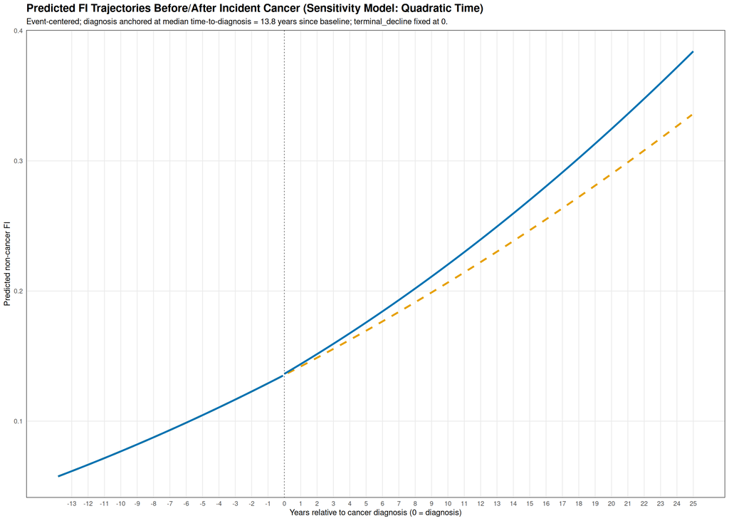

```r
# Use the model frame to guarantee factor levels match what mod_sen3 expects
mf <- model.frame(mod_sen3)

ref_level <- function(x) {
  tab <- table(x)
  if ("Missing" %in% names(tab)) tab <- tab[names(tab) != "Missing"]
  names(which.max(tab))
}

# 1) Anchor diagnosis at the median time-to-diagnosis among cases
#    Identity: years_since_baseline - years_to_cancer = time from baseline to diagnosis (constant per id)
dx_time_by_id <- analysis_long %>%
  filter(!is.na(years_to_cancer)) %>%
  group_by(id) %>%
  summarise(
    everCancer_id = as.integer(any(!is.na(cancer_dateca))),
    tDx = min(years_since_baseline - years_to_cancer, na.rm = TRUE),
    .groups = "drop"
  ) %>%
  filter(everCancer_id == 1L)

tDx_median <- median(dx_time_by_id$tDx, na.rm = TRUE)

# 2) Event-centered window (paper-style)
min_rel <- -15
max_rel <-  25

# Prevent negative years_since_baseline in prediction grid
if (tDx_median + min_rel < 0) min_rel <- -tDx_median

# 3) Build prediction grids
grid_never <- tibble(tRel = seq(min_rel, max_rel, by = 0.25)) %>%
  mutate(
    scenario = "Never cancer (counterfactual)",
    years_since_baseline = tDx_median + tRel,
    Cancer_Status = 0L,
    Years_Since_Cancer = 0
  )

grid_cancer_pre <- tibble(tRel = seq(min_rel, 0, by = 0.25)) %>%
  mutate(
    scenario = "Incident cancer at t=0",
    years_since_baseline = tDx_median + tRel,
    Cancer_Status = 0L,
    Years_Since_Cancer = 0
  )

grid_cancer_post <- tibble(tRel = seq(0, max_rel, by = 0.25)) %>%
  mutate(
    scenario = "Incident cancer at t=0",
    years_since_baseline = tDx_median + tRel,
    Cancer_Status = 1L,
    Years_Since_Cancer = tRel
  )

grid_rel <- bind_rows(grid_never, grid_cancer_pre, grid_cancer_post)

# 4) Set all remaining covariates exactly as required by mod_sen3
grid_rel <- grid_rel %>%
  mutate(
    # fixed effects only; set a non-terminal reference trajectory
    terminal_decline = 0L,

    # set mean age (z-score)
    base_age_z = 0,

    # set reference categories with factor levels exactly matching the fitted model
    base_race    = factor(ref_level(mf$base_race),    levels = levels(mf$base_race)),
    base_marital = factor(ref_level(mf$base_marital), levels = levels(mf$base_marital)),
    base_living  = factor(ref_level(mf$base_living),  levels = levels(mf$base_living)),
    base_pckgr   = factor(ref_level(mf$base_pckgr),   levels = levels(mf$base_pckgr)),

    # include an id (even though re.form = NA), using an existing model-frame level
    id = mf$id[1]
  )

# 5) Predict population-average (fixed-effect) values
grid_rel$pred_FI <- predict(mod_sen3, newdata = grid_rel, re.form = NA)

# Split for plotting
grid_never_plot <- grid_rel %>% filter(scenario == "Never cancer (counterfactual)")
grid_pre_plot   <- grid_rel %>% filter(scenario == "Incident cancer at t=0", Cancer_Status == 0L)
grid_post_plot  <- grid_rel %>% filter(scenario == "Incident cancer at t=0", Cancer_Status == 1L)

# Jump at t=0
y_pre_jump  <- grid_pre_plot  %>% filter(dplyr::near(tRel, 0)) %>% pull(pred_FI)
y_post_jump <- grid_post_plot %>% filter(dplyr::near(tRel, 0)) %>% pull(pred_FI)

# 6) Plot
ggplot() +
  geom_line(data = grid_never_plot, aes(x = tRel, y = pred_FI),
            color = "#E69F00", linetype = "dashed", linewidth = 1.2) +
  geom_line(data = grid_pre_plot, aes(x = tRel, y = pred_FI),
            color = "#0072B2", linewidth = 1.2) +
  geom_line(data = grid_post_plot, aes(x = tRel, y = pred_FI),
            color = "#0072B2", linewidth = 1.2) +
  geom_segment(aes(x = 0, xend = 0, y = y_pre_jump, yend = y_post_jump),
               color = "#0072B2", linewidth = 1.2) +
  geom_vline(xintercept = 0, linetype = "dotted", color = "gray30") +
  scale_x_continuous(breaks = seq(ceiling(min_rel), floor(max_rel), by = 1)) +
  theme_minimal() +
  theme(
    panel.grid.minor = element_blank(),
    panel.border = element_rect(color = "black", fill = NA, linewidth = 0.5),
    plot.title = element_text(face = "bold", size = 15),
    legend.position = "bottom"
  ) +
  labs(
    title = "Predicted FI Trajectories Before/After Incident Cancer (Sensitivity Model: Quadratic Time)",
    subtitle = paste0(
      "Event-centered; diagnosis anchored at median time-to-diagnosis = ",
      round(tDx_median, 1), " years since baseline; terminal_decline fixed at 0."
    ),
    x = "Years relative to cancer diagnosis (0 = diagnosis)",
    y = "Predicted non-cancer FI"
  )
```

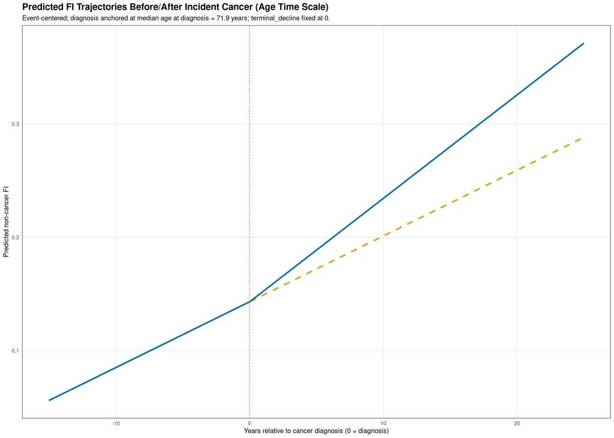

```r
# Use model.frame to guarantee factor levels match mod_sen4
mf <- model.frame(mod_sen4)

ref_level <- function(x) {
  tab <- table(x)
  if ("Missing" %in% names(tab)) tab <- tab[names(tab) != "Missing"]
  names(which.max(tab))
}

# 1) Choose an age anchor for diagnosis (age at cancer among cases)
#    Because the model time scale is age_at_cycle, an event-centered plot needs
#    an "age at diagnosis" anchor: age_at_dx = age_at_cycle - years_to_cancer
dx_age_by_id <- analysis_long %>%
  filter(!is.na(years_to_cancer) & !is.na(age_at_cycle)) %>%
  group_by(id) %>%
  summarise(
    everCancer_id = as.integer(any(!is.na(cancer_dateca))),
    age_at_dx = min(age_at_cycle - years_to_cancer, na.rm = TRUE),
    .groups = "drop"
  ) %>%
  filter(everCancer_id == 1L)

age_dx_median <- median(dx_age_by_id$age_at_dx, na.rm = TRUE)

# 2) Event-centered window (years relative to diagnosis)
min_rel <- -15
max_rel <-  25

# Guardrails: keep ages plausible (optional)
age_min_allowed <- max(0, min(mf$age_at_cycle, na.rm = TRUE))
age_max_allowed <- max(mf$age_at_cycle, na.rm = TRUE)

# 3) Build prediction grids
grid_never <- tibble(tRel = seq(min_rel, max_rel, by = 0.25)) %>%
  mutate(
    scenario = "Never cancer (counterfactual)",
    age_at_cycle = age_dx_median + tRel,
    Cancer_Status = 0L,
    Years_Since_Cancer = 0
  )

grid_cancer_pre <- tibble(tRel = seq(min_rel, 0, by = 0.25)) %>%
  mutate(
    scenario = "Incident cancer at t=0",
    age_at_cycle = age_dx_median + tRel,
    Cancer_Status = 0L,
    Years_Since_Cancer = 0
  )

grid_cancer_post <- tibble(tRel = seq(0, max_rel, by = 0.25)) %>%
  mutate(
    scenario = "Incident cancer at t=0",
    age_at_cycle = age_dx_median + tRel,
    Cancer_Status = 1L,
    Years_Since_Cancer = tRel
  )

grid_rel <- bind_rows(grid_never, grid_cancer_pre, grid_cancer_post) %>%
  # (Optional) clip to observed age range to avoid extrapolation
  mutate(age_at_cycle = pmin(pmax(age_at_cycle, age_min_allowed), age_max_allowed))

# 4) Set remaining covariates to a reference profile with correct factor levels
grid_rel <- grid_rel %>%
  mutate(
    terminal_decline = 0L,  # set to 0 (change to 1 to visualize last-year-of-life scenario)
    base_race    = factor(ref_level(mf$base_race),    levels = levels(mf$base_race)),
    base_marital = factor(ref_level(mf$base_marital), levels = levels(mf$base_marital)),
    base_living  = factor(ref_level(mf$base_living),  levels = levels(mf$base_living)),
    base_pckgr   = factor(ref_level(mf$base_pckgr),   levels = levels(mf$base_pckgr)),
    id = mf$id[1]  # not used when re.form=NA, but harmless if id is in the model frame
  )

# 5) Predict fixed-effect trajectories (population-average)
grid_rel$pred_FI <- predict(mod_sen4, newdata = grid_rel, re.form = NA)

# 6) Jump at t=0
grid_pre  <- grid_rel %>% filter(scenario == "Incident cancer at t=0", Cancer_Status == 0L)
grid_post <- grid_rel %>% filter(scenario == "Incident cancer at t=0", Cancer_Status == 1L)

y_pre_jump  <- grid_pre  %>% filter(dplyr::near(tRel, 0)) %>% pull(pred_FI)
y_post_jump <- grid_post %>% filter(dplyr::near(tRel, 0)) %>% pull(pred_FI)

# 7) Plot
ggplot() +
  geom_line(data = grid_rel %>% filter(scenario == "Never cancer (counterfactual)"),
            aes(x = tRel, y = pred_FI),
            color = "#E69F00", linetype = "dashed", linewidth = 1.2) +
  geom_line(data = grid_pre,  aes(x = tRel, y = pred_FI),
            color = "#0072B2", linewidth = 1.2) +
  geom_line(data = grid_post, aes(x = tRel, y = pred_FI),
            color = "#0072B2", linewidth = 1.2) +
  geom_segment(aes(x = 0, xend = 0, y = y_pre_jump, yend = y_post_jump),
               color = "#0072B2", linewidth = 1.2) +
  geom_vline(xintercept = 0, linetype = "dotted", color = "gray30") +
  theme_minimal() +
  theme(
    panel.grid.minor = element_blank(),
    panel.border = element_rect(color = "black", fill = NA, linewidth = 0.5),
    plot.title = element_text(face = "bold", size = 15),
    legend.position = "bottom"
  ) +
  labs(
    title = "Predicted FI Trajectories Before/After Incident Cancer (Age Time Scale)",
    subtitle = paste0(
      "Event-centered; diagnosis anchored at median age at diagnosis = ",
      round(age_dx_median, 1), " years; terminal_decline fixed at 0."
    ),
    x = "Years relative to cancer diagnosis (0 = diagnosis)",
    y = "Predicted non-cancer FI"
  )
```